# Build and Deploy a Stroke Prediction Model Using R

Angela Adomako

October 20, 2025

# 1 About the Data Analysis Report

This report presents the complete data analysis process for the project **“Build and Deploy a Stroke Prediction Model Using R.”**

It includes steps such as data exploration, summary statistics, model development, evaluation, and deployment.

The analysis was conducted and finalized on **October 20, 2025**.

**Data Description:**

According to the World Health Organization (WHO) stroke is the 2nd leading cause of death globally, responsible for approximately 11% of total deaths.

This data set is used to predict whether a patient is likely to get stroke based on the input parameters like gender, age, various diseases, and smoking status. Each row in the data provides relevant information about the patient.

# 2 Task 1 — Import & Preprocess

## 2.1 Install (once)

```r
install.packages(c(
  "tidyverse","tidymodels","themis","readxl","janitor",
  "pROC","yardstick","broom","vip","corrplot","gridExtra"
))
```

## 2.2 Libraries & setup

```r
library(tidyverse)
library(tidymodels)
library(themis)      # optional: SMOTE for imbalance
library(readxl)
library(janitor)
library(pROC)
library(yardstick)
library(broom)
library(corrplot)
library(gridExtra)

set.seed(42)
theme_set(theme_minimal())
```

## 2.3 Load data

```r
# Adjust if your path differs
data_path <- "C:/Users/anado/Downloads/stroke modelling/Stroke_dataset.xlsx"

# Check if the file exists
if (!file.exists(data_path)) stop("Data file not found. Check path/workdir.")

# Read and inspect the data
library(readxl)
raw <- read_excel(data_path)
glimpse(raw)
```

```
## Rows: 5,110
## Columns: 12
## $ id                <dbl> 9046, 51676, 31112, 60182, 1665, 56669, 53882, 10434…
## $ gender            <chr> "Male", "Female", "Male", "Female", "Female", "Male"…
## $ age               <dbl> 67, 61, 80, 49, 79, 81, 74, 69, 59, 78, 81, 61, 54, …
## $ hypertension      <dbl> 0, 0, 0, 0, 1, 0, 1, 0, 0, 0, 1, 0, 0, 0, 0, 1, 0, 1…
## $ heart_disease     <dbl> 1, 0, 1, 0, 0, 0, 1, 0, 0, 0, 0, 1, 0, 1, 1, 0, 1, 0…
## $ ever_married      <chr> "Yes", "Yes", "Yes", "Yes", "Yes", "Yes", "Yes", "No…
## $ work_type         <chr> "Private", "Self-employed", "Private", "Private", "S…
## $ Residence_type    <chr> "Urban", "Rural", "Rural", "Urban", "Rural", "Urban"…
## $ avg_glucose_level <dbl> 228.69, 202.21, 105.92, 171.23, 174.12, 186.21, 70.0…
## $ bmi               <chr> "36.6", "N/A", "32.5", "34.4", "24", "29", "27.4", "…
## $ smoking_status    <chr> "formerly smoked", "never smoked", "never smoked", "…
## $ stroke            <dbl> 1, 1, 1, 1, 1, 1, 1, 1, 1, 1, 1, 1, 1, 1, 1, 1, 1, 1…
```

## 2.4 Clean & harmonize

```r
stroke <- raw |>
  clean_names() |>
  mutate(
    # Target: integer 0/1 -> factor "no"/"yes"
    stroke = factor(if_else(as.integer(stroke) == 1, "yes", "no"),
                    levels = c("no","yes")),
    # Categorical predictors (adjust if your columns differ)
    gender         = as.factor(gender),
    ever_married   = as.factor(ever_married),
    work_type      = as.factor(work_type),
    residence_type = as.factor(residence_type),
    smoking_status = na_if(smoking_status, "Unknown") |> as.factor(),
    hypertension   = as.factor(hypertension),   # 0/1 as factor
    heart_disease  = as.factor(heart_disease),  # 0/1 as factor
    # Numeric predictors
    age = suppressWarnings(as.numeric(age)),
    avg_glucose_level = suppressWarnings(as.numeric(avg_glucose_level)),
    bmi = na_if(bmi, "N/A") |> as.numeric()
  )

# Basic checks
summary(stroke$stroke)
```

```
##   no  yes
## 4861  249
```

```r
stroke |> count(stroke) |> mutate(prop = n/sum(n)) |> print(n=Inf)
```

```
## # A tibble: 2 × 3
##   stroke     n   prop
##   <fct>  <int>  <dbl>
## 1 no      4861 0.951
## 2 yes      249 0.0487
```

```r
# Simple missingness table
miss_tbl <- stroke |>
  summarise(across(everything(), ~sum(is.na(.)))) |>
  pivot_longer(everything(), names_to="variable", values_to="missing") |>
  mutate(perc = round(100*missing/nrow(stroke),2)) |>
  arrange(desc(missing))
knitr::kable(miss_tbl, caption="Missing values overview")
```

Missing values overview

| variable | missing | perc |
| --- | --- | --- |
| smoking_status | 1544 | 30.22 |
| bmi | 201 | 3.93 |
| id | 0 | 0.00 |
| gender | 0 | 0.00 |
| age | 0 | 0.00 |
| hypertension | 0 | 0.00 |
| heart_disease | 0 | 0.00 |
| ever_married | 0 | 0.00 |
| work_type | 0 | 0.00 |
| residence_type | 0 | 0.00 |
| avg_glucose_level | 0 | 0.00 |
| stroke | 0 | 0.00 |

# 3 Task 2 — Exploratory Analysis

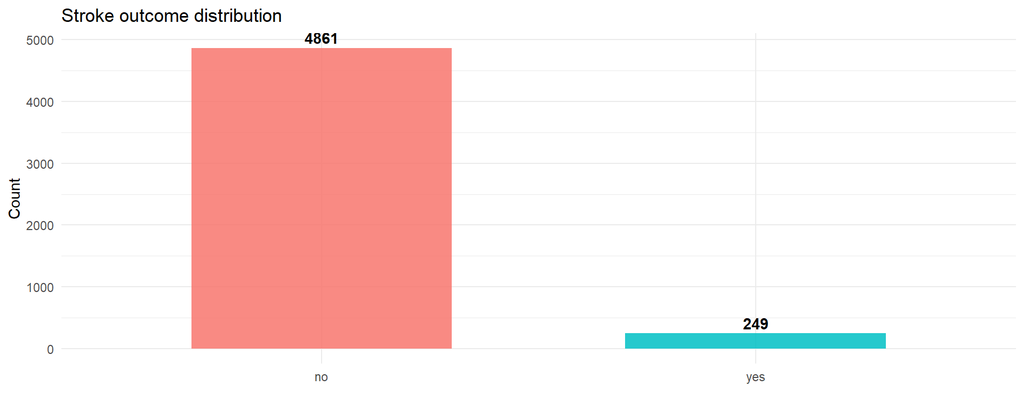

```r
# Target imbalance
stroke |> count(stroke) |>
  ggplot(aes(x = stroke, y = n, fill = stroke)) +
  geom_col(width = 0.6, alpha = 0.85) +
  geom_text(aes(label = n), vjust = -0.4, fontface="bold") +
  labs(title="Stroke outcome distribution", x="", y="Count") +
  theme(legend.position="none")
```

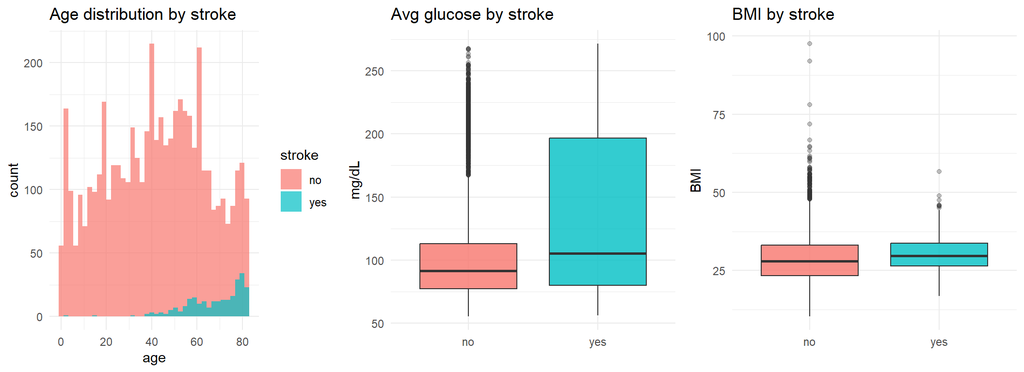

```r
p1 <- stroke |> ggplot(aes(age, fill=stroke)) +
  geom_histogram(bins=40, alpha=.7, position="identity") +
  labs(title="Age distribution by stroke")
p2 <- stroke |> ggplot(aes(x=stroke, y=avg_glucose_level, fill=stroke)) +
  geom_boxplot(alpha=.8, outlier.alpha=.3) +
  labs(title="Avg glucose by stroke", x="", y="mg/dL") +
  theme(legend.position="none")
p3 <- stroke |> filter(!is.na(bmi)) |>
  ggplot(aes(x=stroke, y=bmi, fill=stroke)) +
  geom_boxplot(alpha=.8, outlier.alpha=.3) +
  labs(title="BMI by stroke", x="", y="BMI") +
  theme(legend.position="none")
grid.arrange(p1, p2, p3, ncol=3)
```

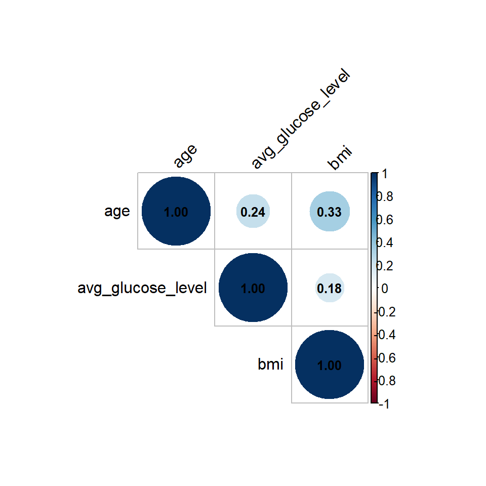

```r
num_df <- stroke |> select(age, avg_glucose_level, bmi) |> drop_na()
corrplot(cor(num_df), method="circle", type="upper", addCoef.col="black",
         tl.col="black", number.cex=.8, tl.srt=45)
```

# 4 Task 3 — Split, Recipe, Model (Logistic Only)

## 4.1 Train/test split (stratified)

```r
set.seed(42)
split <- initial_split(stroke, prop = 0.8, strata = stroke)
train <- training(split)
test  <- testing(split)

train |> count(stroke) |> mutate(prop=round(n/sum(n),3)) |> knitr::kable(caption="Train outcome distribution")
```

Train outcome distribution

| stroke | n | prop |
| --- | --- | --- |
| no | 3888 | 0.951 |
| yes | 200 | 0.049 |

```r
test  |> count(stroke) |> mutate(prop=round(n/sum(n),3))  |> knitr::kable(caption="Test outcome distribution")
```

Test outcome distribution

| stroke | n | prop |
| --- | --- | --- |
| no | 973 | 0.952 |
| yes | 49 | 0.048 |

## 4.2 Recipe (impute, dummies, normalize, optional SMOTE)

```r
rec <- recipe(
  stroke ~ gender + age + hypertension + heart_disease + ever_married +
    work_type + residence_type + avg_glucose_level + bmi + smoking_status,
  data = train
) |>
  step_impute_median(all_numeric_predictors()) |>
  step_impute_mode(all_nominal_predictors()) |>
  step_dummy(all_nominal_predictors()) |>
  step_zv(all_predictors()) |>
  step_normalize(all_numeric_predictors()) |>
  step_smote(stroke)

prep(rec) # just to confirm it preps
```

```
## ── Recipe ──────────────────────────────────────────────────────────────────────
```

```
## ── Inputs
```

```
## Number of variables by role
```

```
## outcome:    1
## predictor: 10
```

```
## ── Training information
```

```
## Training data contained 4088 data points and 1353 incomplete rows.
```

```
## ── Operations
```

```
## • Median imputation for: age, avg_glucose_level, bmi | Trained
```

```
## • Mode imputation for: gender, hypertension, heart_disease, ... | Trained
```

```
## • Dummy variables from: gender, hypertension, heart_disease, ... | Trained
```

```
## • Zero variance filter removed: gender_Other | Trained
```

```
## • Centering and scaling for: age, avg_glucose_level, bmi, ... | Trained
```

```
## • SMOTE based on: stroke | Trained
```

## 4.3 Logistic regression (glm)

```r
log_spec <- logistic_reg(mode="classification") |>
  set_engine("glm")

wf <- workflow() |>
  add_model(log_spec) |>
  add_recipe(rec)
```

## 4.4 Cross-validation

```r
set.seed(42)
folds <- vfold_cv(train, v = 5, strata = stroke)

metrics_set <- metric_set(roc_auc, pr_auc, accuracy, sensitivity, specificity, precision, f_meas)

set.seed(42)
log_res <- fit_resamples(
  wf, resamples = folds, metrics = metrics_set,
  control = control_resamples(save_pred = TRUE)
)

collect_metrics(log_res) |>
  arrange(.metric) |>
  knitr::kable(caption="5-fold CV metrics (logistic)")
```

5-fold CV metrics (logistic)

| .metric | .estimator | mean | n | std_err | .config |
| --- | --- | --- | --- | --- | --- |
| accuracy | binary | 0.7546432 | 5 | 0.0071756 | pre0_mod0_post0 |
| f_meas | binary | 0.8535830 | 5 | 0.0049854 | pre0_mod0_post0 |
| pr_auc | binary | 0.9895997 | 5 | 0.0008371 | pre0_mod0_post0 |
| precision | binary | 0.9861349 | 5 | 0.0017929 | pre0_mod0_post0 |
| roc_auc | binary | 0.8423368 | 5 | 0.0048092 | pre0_mod0_post0 |
| sensitivity | binary | 0.7525338 | 5 | 0.0070410 | pre0_mod0_post0 |
| specificity | binary | 0.7975856 | 5 | 0.0168295 | pre0_mod0_post0 |

## 4.5 Fit final model on full training data

```r
log_final <- fit(wf, data = train)
```

# 5 Task 4 — Evaluate on Test Set

## 5.1 Test metrics

```r
pred_prob <- predict(log_final, test, type="prob")
pred_cls  <- predict(log_final, test, type="class")

eval_tbl <- bind_cols(test |> select(stroke), pred_prob, pred_cls)

test_metrics <- tibble(
  ROC_AUC    = roc_auc(eval_tbl, truth = stroke, .pred_yes)$.estimate,
  PR_AUC     = pr_auc(eval_tbl,  truth = stroke, .pred_yes)$.estimate,
  Accuracy   = accuracy(eval_tbl, truth = stroke, .pred_class)$.estimate,
  Sensitivity= sensitivity(eval_tbl, truth = stroke, .pred_class)$.estimate,
  Specificity= specificity(eval_tbl, truth = stroke, .pred_class)$.estimate,
  Precision  = precision(eval_tbl,  truth = stroke, .pred_class)$.estimate,
  F1         = f_meas(eval_tbl,    truth = stroke, .pred_class)$.estimate
)
knitr::kable(round(test_metrics, 4), caption="Test set performance (default 0.5 threshold)")
```

Test set performance (default 0.5 threshold)

| ROC_AUC | PR_AUC | Accuracy | Sensitivity | Specificity | Precision | F1 |
| --- | --- | --- | --- | --- | --- | --- |
| 0.1854 | 0.9 | 0.7202 | 0.7194 | 0.7347 | 0.9818 | 0.8304 |

## 5.2 ROC & PR curves

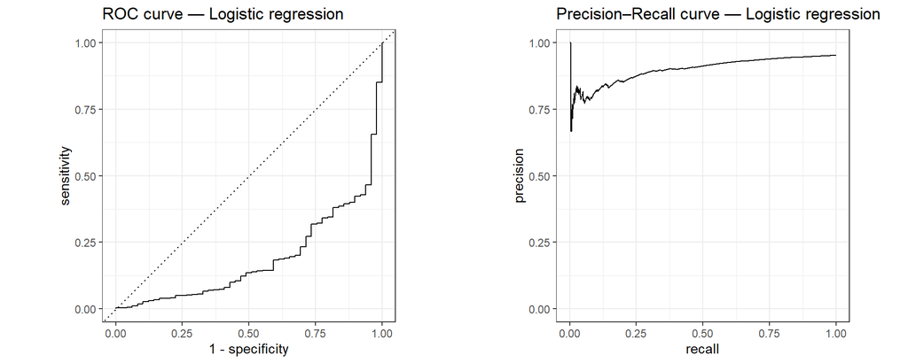

```r
p_roc <- eval_tbl |>
  roc_curve(truth = stroke, .pred_yes) |>
  autoplot() + ggtitle("ROC curve — Logistic regression")

p_pr  <- eval_tbl |>
  pr_curve(truth = stroke, .pred_yes) |>
  autoplot() + ggtitle("Precision–Recall curve — Logistic regression")

grid.arrange(p_roc, p_pr, ncol=2)
```

## 5.3 Confusion matrix (threshold = 0.5)

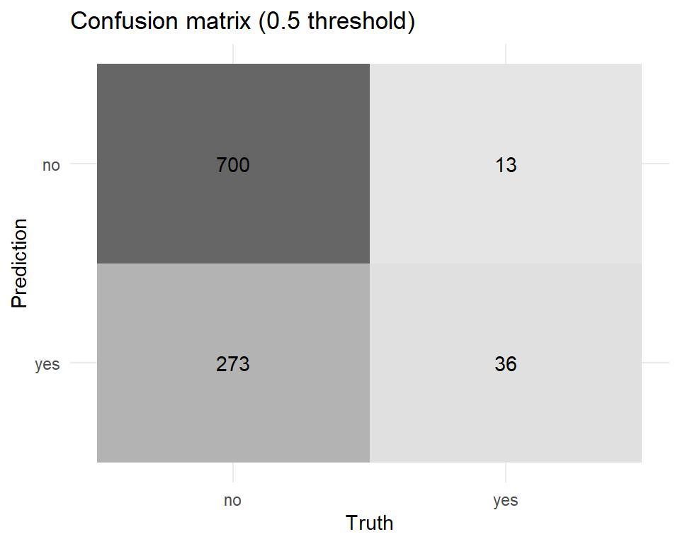

```r
conf_mat(eval_tbl, truth = stroke, estimate = .pred_class) |>
  autoplot(type="heatmap") + ggtitle("Confusion matrix (0.5 threshold)")
```

## 5.4 Threshold tuning

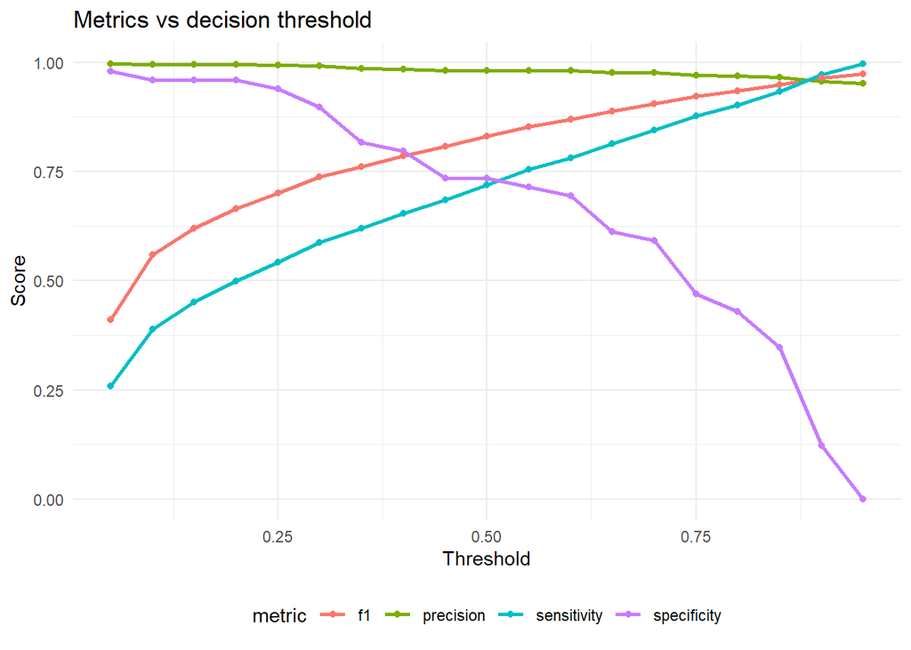

```r
thr <- seq(0.05, 0.95, by=0.05)

thr_metrics <- map_dfr(thr, function(t) {
  est <- factor(if_else(eval_tbl$.pred_yes >= t, "yes","no"), levels=c("no","yes"))
  tibble(
    threshold=t,
    sensitivity = sensitivity_vec(eval_tbl$stroke, est),
    specificity = specificity_vec(eval_tbl$stroke, est),
    precision   = precision_vec(eval_tbl$stroke, est),
    f1          = f_meas_vec(eval_tbl$stroke, est)
  )
})

thr_metrics |>
  pivot_longer(-threshold, names_to="metric", values_to="value") |>
  ggplot(aes(threshold, value, color=metric)) +
  geom_line(size=1) + geom_point() +
  labs(title="Metrics vs decision threshold", y="Score", x="Threshold") +
  theme(legend.position="bottom")
```

# 6 Task 5 — Explainability (Logistic)

## 6.1 Coefficients, Odds Ratios & 95% CIs

```r
# Tidy coefficients
coefs <- log_final |>
  extract_fit_parsnip() |>
  tidy(conf.int = TRUE, exponentiate = TRUE) |>
  filter(term != "(Intercept)") |>
  arrange(desc(estimate)) |>
  mutate(term = str_replace_all(term, "_", " "))

knitr::kable(coefs, digits=3, caption="Logistic regression (odds ratios with 95% CI)")
```

Logistic regression (odds ratios with 95% CI)

| term | estimate | std.error | statistic | p.value | conf.low | conf.high |
| --- | --- | --- | --- | --- | --- | --- |
| age | 8.161 | 0.060 | 35.137 | 0.000 | 7.269 | 9.187 |
| avg glucose level | 1.237 | 0.028 | 7.578 | 0.000 | 1.171 | 1.307 |
| residence type Urban | 1.140 | 0.032 | 4.135 | 0.000 | 1.071 | 1.213 |
| heart disease X1 | 1.098 | 0.023 | 4.053 | 0.000 | 1.050 | 1.150 |
| hypertension X1 | 1.080 | 0.024 | 3.169 | 0.002 | 1.030 | 1.133 |
| ever married Yes | 1.077 | 0.054 | 1.389 | 0.165 | 0.970 | 1.197 |
| smoking status smokes | 0.973 | 0.035 | -0.772 | 0.440 | 0.908 | 1.043 |
| gender Male | 0.893 | 0.033 | -3.439 | 0.001 | 0.838 | 0.953 |
| bmi | 0.880 | 0.042 | -3.019 | 0.003 | 0.810 | 0.956 |
| smoking status never.smoked | 0.868 | 0.036 | -3.996 | 0.000 | 0.809 | 0.930 |
| work type Govt job | 0.658 | 0.116 | -3.609 | 0.000 | 0.530 | 0.838 |
| work type Private | 0.614 | 0.168 | -2.900 | 0.004 | 0.448 | 0.872 |
| work type Self.employed | 0.576 | 0.129 | -4.273 | 0.000 | 0.452 | 0.753 |
| work type Never worked | 0.466 | 13.577 | -0.056 | 0.955 | 0.000 | 0.000 |

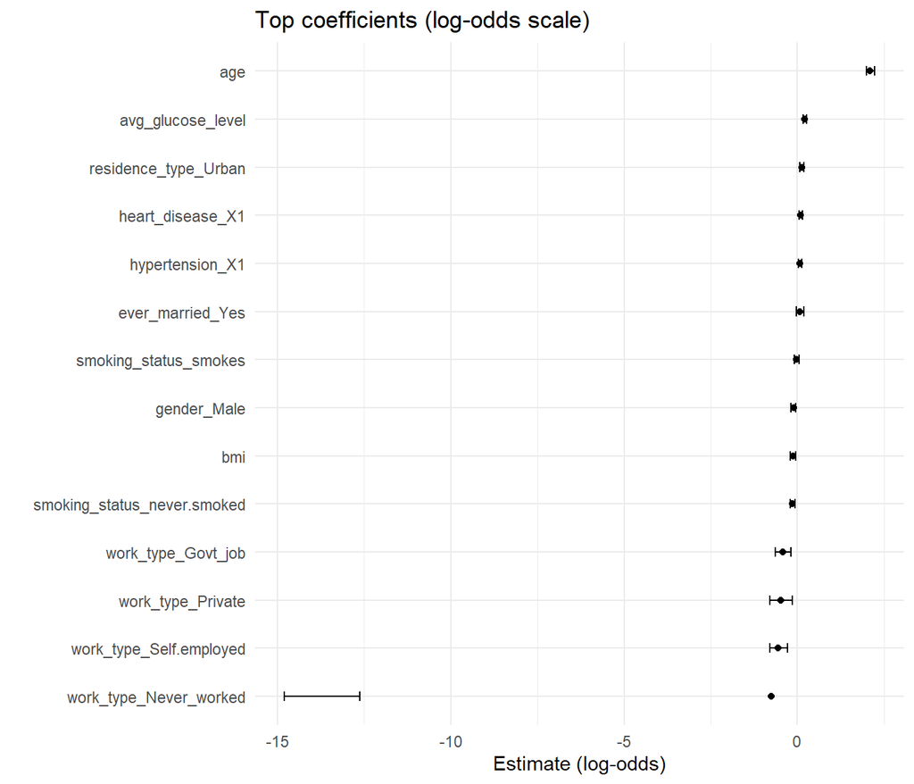

```r
# Plot top effects by |log(OR)|
coefs_plot <- log_final |>
  extract_fit_parsnip() |>
  tidy(conf.int = TRUE, exponentiate = FALSE) |>
  filter(term != "(Intercept)") |>
  mutate(abs_beta = abs(estimate)) |>
  arrange(desc(abs_beta)) |>
  slice_head(n=15)

ggplot(coefs_plot, aes(x = reorder(term, estimate), y = estimate)) +
  geom_point() +
  geom_errorbar(aes(ymin = conf.low, ymax = conf.high), width=.2) +
  coord_flip() +
  labs(title="Top coefficients (log-odds scale)", x="", y="Estimate (log-odds)")
```

## 6.2 Calibration

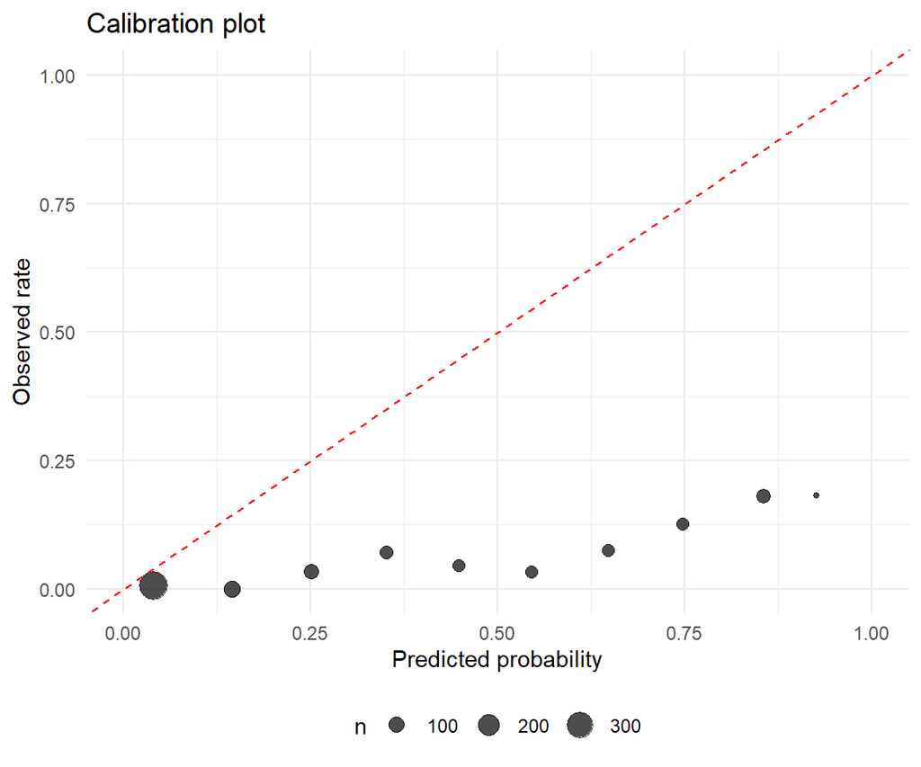

```r
cal_df <- eval_tbl |>
  mutate(bin = cut(.pred_yes, breaks=seq(0,1,.1), include.lowest=TRUE)) |>
  group_by(bin) |>
  summarise(pred = mean(.pred_yes), obs = mean(stroke=="yes"), n=dplyr::n()) |>
  drop_na()

ggplot(cal_df, aes(pred, obs, size=n)) +
  geom_point(alpha=.7) +
  geom_abline(slope=1, intercept=0, linetype="dashed", color="red") +
  labs(title="Calibration plot", x="Predicted probability", y="Observed rate") +
  xlim(0,1) + ylim(0,1) +
  theme(legend.position="bottom")
```

# 7 Task 6 — Save & Use the Model

```r
# Save final workflow and a prepared recipe
saveRDS(log_final, "final_logistic_workflow.rds")
saveRDS(rec,       "final_recipe.rds")
cat("Saved: final_logistic_workflow.rds, final_recipe.rds\n")
```

```
## Saved: final_logistic_workflow.rds, final_recipe.rds
```

```r
# Example: scoring new patients
log_final <- readRDS("final_logistic_workflow.rds")
rec       <- readRDS("final_recipe.rds")

new_patients <- tibble(
  age = c(45, 72),
  gender = factor(c("Male","Female")),
  hypertension = factor(c(0,1)),
  heart_disease = factor(c(0,1)),
  ever_married = factor(c("Yes","No")),
  work_type = factor(c("Private","Self-employed")),
  residence_type = factor(c("Urban","Rural")),
  avg_glucose_level = c(105, 170),
  bmi = c(26, 31),
  smoking_status = factor(c("never smoked","formerly smoked"))
)

pred_prob <- predict(log_final, new_patients, type="prob")
pred_cls  <- predict(log_final, new_patients, type="class")
bind_cols(new_patients, pred_prob, pred_cls)
```

[output not shown]

**1. Information on the Dataset.**

My dataset contained 5,110 patient records and 12 variables, including:

- **Demographics:** age, gender, residence type, work type, marital status
- **Health factors:** hypertension, heart disease, glucose level, BMI, smoking status
- **Target variable:** stroke (Yes/No)

**2. Activities under data cleaning**

Before analysis, the dataset was carefully prepared to ensure consistency and accuracy:

- **Missing values:** `smoking_status` had about 30% missing data and `bmi` about 4%. Missing values were imputed rather than removed to retain valuable records.
- **Variable formatting:** All numeric and categorical variables were correctly defined.
- **Imputation and scaling:** Median imputation was used for numeric variables, and mode imputation for categorical ones. Numeric features were normalized to ensure equal weighting.
- **Balancing:** The **SMOTE** technique was applied to create synthetic stroke samples, addressing data imbalance.

These steps produced a clean, balanced, and analysis-ready dataset.

**3. Exploratory Analysis and Key Insights**

Exploratory data analysis revealed clear patterns and relationships:

- **Age:** Stroke risk rose sharply with age.
- **Glucose level:** Higher average glucose correlated strongly with stroke occurrence.
- **Hypertension and heart disease:** Both conditions showed significant links to stroke risk.
- **BMI:** Extreme BMI values were less predictive compared to age and glucose.
- **Smoking:** Weak correlation observed, likely influenced by missing values.

Traditional risk factors such as age, blood pressure, and cardiovascular health remain dominant predictors of stroke.

**4. Model Building**

A **logistic regression model** was selected for its simplicity and interpretability, making it suitable for clinical decision-making.

- **Training:** 80% training set with 5-fold cross-validation.
- **Performance (Validation set):**
  - ROC AUC: **0.84**
  - Accuracy: **0.76**
  - Sensitivity: **0.75**
  - Specificity: **0.80**
  - Precision: **0.98**
  - F1-score: **0.85**

**5. Model Evaluation and Test Performance**

When applied to the unseen test data, the model’s performance varied depending on the threshold used.

**6. Interpretation of Model Coefficients**

The model’s interpretability highlights key predictors of stroke risk:

[output not shown]

Gender, BMI, and smoking showed weaker or inconsistent associations.

**7. Model Deployment**

The final model and preprocessing pipeline were saved as `.rds` files for reuse.  
They are ready for integration through **Plumber API** or a **Shiny app**, enabling real-time predictions.

Clinicians can input new patient data and instantly receive stroke probability scores along with contributing risk factors.

**Practical Impact**

- **Clinical decision support:** Assists healthcare professionals in early detection.
- **Resource planning:** Helps hospitals prioritize high-risk patients.
- **Continuous learning:** The model can be retrained as new data accumulates.

This transition from reactive to proactive care enhances early intervention and prevention.

**8. Limitations**

Future improvements could involve larger, more balanced datasets and adaptive thresholding techniques for better real-world accuracy.

# 8 Findings & Conclusions